# 6.9 Advanced gradient based methods

code

share

► [Chapter 6: First order methods](https://jermwatt.github.io/mlrefined/index.html)  
6.9 Advanced gradient based methods

- We have described two fundamental problems of the negative gradient insofar as it is used as a descent direction for local optimization: the zig-zagging and slow-crawling behaviors.
- We have also now detailed general solutions to these problems, in the form of momentum and normalization
- These two fundamental problems can certainly occur together in practice, particularly with the sort of functions we minimize in machine learning. They both occur with functions that have long narrow valleys - of the sort that provoke zig-zagging due to the shape of their contours - that are also considerably flat - provoking the sort of crawling behavior detailed above.
- To this end many advanced first order gradient based methods have been developed in the machine learning community that essentially combine momentum and normalization in various ways
- In this Section we will detail a few of these methods, highlighting their connection to our two solutions methods

# RMSPROP

- Most popular methods average the component-wise normalization - i.e., the magnitude of each partial derivative - replacing it with some sort of moving / exponential average of its past
- In the case of an exponential average, let $h_j^{k}$ denotes the exponential average of of the squared magnitude of the $j^{th}$ partial derivative at step $k$

\begin{equation} h_j^k = \gamma \, h_j^{k-1} + \left(1 - \gamma\right)\left(\frac{\partial}{\partial w_j}g\left(\mathbf{w}^{k-1}\right)\right)^2 \end{equation}

- A gradient descent method that moves according a negative gradient with exponentially normalized partial derivatives then consists of two steps per update: 1) updating the exponential average of each partial derivative magnitude and 2) moving in this direction

\begin{equation} h_j^k = \gamma \, h_j^{k-1} + \left(1 - \gamma\right)\left(\frac{\partial}{\partial w_j}g\left(\mathbf{w}^{k-1}\right)\right)^2 \\ w_j^k = w_j^{k-1} - \alpha \frac{\frac{\partial}{\partial w_j} g\left(\mathbf{w}^{k-1}\right)}{\sqrt{h_j^{k-1}}} \,\,\,\,\,\,\,\,\,\,\,\,\,\,\,\,\,\,\,\,\,\,\,\,\, \end{equation}

- This is often called RMSprop (Root Mean Squared Propogation) - and again many other popular first order methods (e.g., Adam, AdaDelta, etc.,) are quite similar
- As with the standard normalized methods, in practice a small nonnegative $\epsilon > 0$ is typcally added to the denominator of the second line to avoid dividing by zero

\begin{equation} h_j^k = \gamma \, h_j^{k-1} + \left(1 - \gamma\right)\left(\frac{\partial}{\partial w_j}g\left(\mathbf{w}^{k-1}\right)\right)^2 \\ w_j^k = w_j^{k-1} - \alpha \frac{\frac{\partial}{\partial w_j} g\left(\mathbf{w}^{k-1}\right)}{\sqrt{h_j^{k-1}}+ \epsilon} \,\,\,\,\,\,\,\,\,\,\,\,\,\,\,\,\,\,\,\,\,\,\,\,\, \end{equation}

#### Example. Exponential normalized gradient descent - a.k.a. RMSprop

```python
def RMSprop(g,w,alpha,max_its,**kwargs):
    # rmsprop params
    gamma=0.9
    eps=10**-8
    if 'gamma' in kwargs:
        gamma = kwargs['gamma']
    if 'eps' in kwargs:
        eps = kwargs['eps']

    # flatten the input function, create gradient based on flat function
    g_flat, unflatten, w = flatten_func(g, w)
    grad = compute_grad(g_flat)

    # initialize average gradient
    avg_sq_grad = np.ones(np.size(w))

    # record history
    w_hist = [unflatten(w)]

    # over the line
    for k in range(max_its):
        # evaluate and shape grad
        grad_eval = grad(w)
        grad_eval.shape = np.shape(w)

        # update exponential average of past gradients
        avg_sq_grad = gamma*avg_sq_grad + (1 - gamma)*grad_eval**2

        # take descent step
        w = w - alpha*grad_eval / (avg_sq_grad**(0.5) + eps)

        # record weight update, train and val costs
        w_hist.append(unflatten(w))

    return w_hist
```

```python
a = 0
b = 3*np.ones((2,1))
b[1] = 0
C = np.random.rand(2,2)
C = np.dot(C,C.T)
C = np.array([[0,0],[0,20]])

# a quadratic function defined using the constants above
g = lambda w: (a + np.dot(b.T,w) + np.dot(np.dot(w.T,C),w))[0]

# setup initialization
w_init = np.ones((2,1))
w_init[1] = 1.5
w_init[0] = 10

# w_init = np.random.randn(2,1)
alpha = 10**(-2)
max_its = 10
version = 'unnormalized'

# use momentum with beta = 0
beta = 0
weight_history_1 = gradient_descent(g,w_init,alpha,max_its,beta,version)

# component-wise normalization
alpha = 10**(0)
beta = 0
version = 'component_normalized'
weight_history_2 = gradient_descent(g,w_init,alpha,max_its,beta,version)

# component-wise normalization
alpha = 10**(0)
weight_history_3 = RMSprop(g,w_init,alpha,max_its,gamma = 0.9)
```

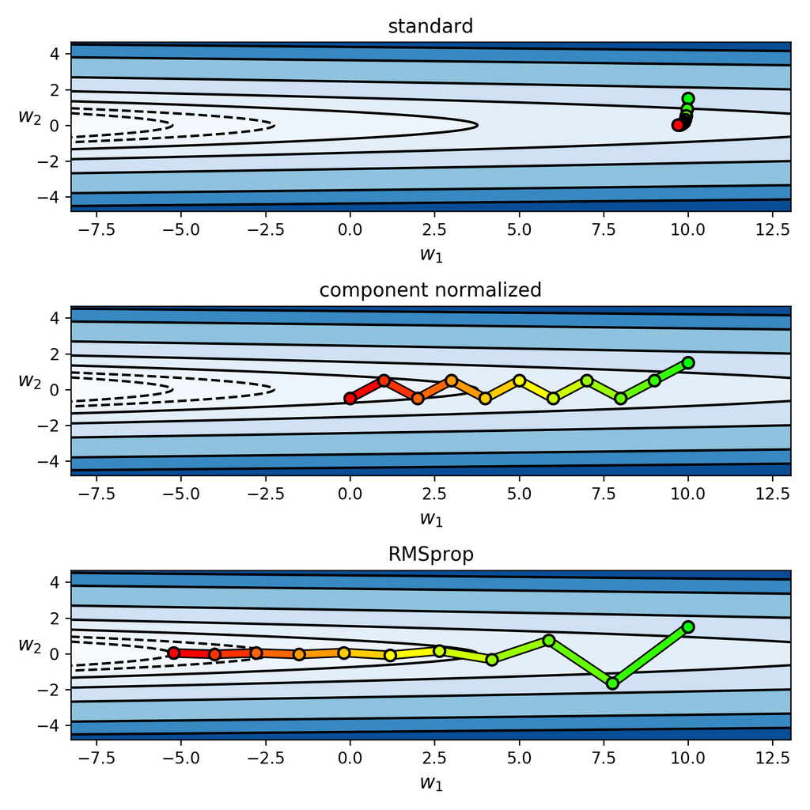

```python
# visualize
w_histories = [weight_history_1,weight_history_2,weight_history_3]
labels = ['standard','component normalized','RMSprop']
demo = nonlib.contour_run_comparison.Visualizer()
demo.show_paths(g,w_histories,labels,num_contours = 20)
```

#### Example. Plotting the value of partial derivatives and their normalized versions

[figure not shown]

```python
# setup network
activation = 'tanh'
layer_sizes = [1,3,3,1]
feats = nonlib.multilayer_perceptron.Setup(activation = activation,layer_sizes = layer_sizes)
feature_transforms = feats.feature_transforms
initializer = feats.initializer

# parameters for our two runs of gradient descent
scale = 0.1
w = np.array([scale*np.random.randn(2,1),scale*np.random.randn(2,1)])

w = initializer()
max_its = 1500; alpha_choice = 10**(-2)

# run on original data
run0 = nonlib.basic_runner.Setup(x,y,feature_transforms,normalize = 'None')
run0.fit(w=w,alpha_choice = alpha_choice,max_its=max_its)

# run on original data
run1 = nonlib.basic_runner.Setup(x,y,feature_transforms,normalize = 'None',version = 'component_normalized')
run1.fit(w=w,alpha_choice = alpha_choice,max_its=max_its)

# run on original data
run2 = nonlib.basic_runner.Setup(x,y,feature_transforms,normalize = 'None',algo = 'RMSprop')
run2.fit(w=w,alpha_choice = alpha_choice,max_its=max_its,gamma = 0.9)
```

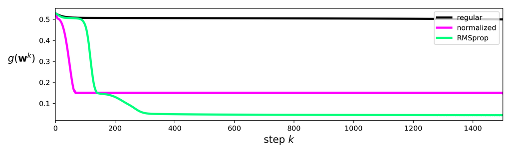

```python
# plot the cost function history for a given run
runs = [run0,run1,run2]
plotter = nonlib.static_plotter.Visualizer()
plotter.plot_cost_histories(runs,start = 0,points = False,labels = ['regular','normalized','RMSprop'])
```

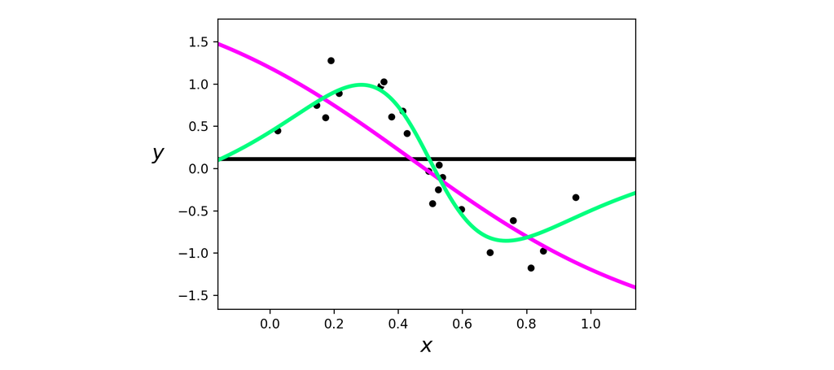

```python
demo.plot_fits(runs)
```

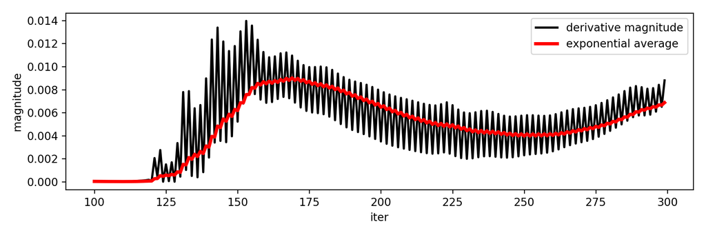

```python
plotter.plot_partial_mags(run2,start = 100,end = 300,parts = [11])
```

© This material is not to be distributed, copied, or reused without written permission from the authors.